# Basics of text analysis

Pablo Barbera

July 31, 2017

This RMarkdown file provides additional information about the basic tools of text analysis that we will use in this course to clean text data scraped from the web.

### String manipulation with R

We will start with basic string manipulation with R.

```r
library(streamR)
tweets <- parseTweets("~/data/trump-tweets.json")
```

```
## 3866 tweets have been parsed.
```

```r
head(tweets)
```

```
##                                                                                                                                                                                                                                                                                       text
## 1 We are gathered today to hear directly from the AMERICAN VICTIMS of ILLEGAL IMMIGRATION. These are the American Citizens permanently separated from their loved ones b/c they were killed by criminal illegal aliens. These are the families the media ignores...https://t.co/ZjXESYAcjY
## 2                                                                                                                                                                             Amy Kremer, Women for Trump, was so great on @foxandfriends. Brave and very smart, thank you Amy! @AmyKremer
## 3                                                                                                                                                                                Thank you South Carolina. Now let’s get out tomorrow and VOTE for @HenryMcMaster! https://t.co/5xlz0wfMfu
## 4                                                                                     Just watched @SharkGregNorman on @foxandfriends. Said “President is doing a great job. All over the world, people want to come back to the U.S.” Thank you Greg, and you’re looking and doing great!
## 5   Russia continues to say they had nothing to do with Meddling in our Election! Where is the DNC Server, and why didn’t Shady James Comey and the now disgraced FBI agents take and closely examine it? Why isn’t Hillary/Russia being looked at? So many questions, so much corruption!
## 6                                                                                                                                                                                                                    Statement on Justice Anthony Kennedy. #SCOTUS https://t.co/8aWJ6fWemA
##   retweet_count favorite_count favorited truncated              id_str
## 1         30514          89162     FALSE     FALSE 1010246126820347906
## 2          9382          50425     FALSE     FALSE 1012297599431401474
## 3         13631          56997     FALSE     FALSE 1011422555947712513
## 4         12007          62025     FALSE     FALSE 1012299239207198721
## 5         23077          92661     FALSE     FALSE 1012295859072126977
## 6         11138          47234     FALSE     FALSE 1012051330591023107
##   in_reply_to_screen_name
```

[output cut: 83 more lines]

R stores the basic string in a character vector. `length` gets the number of items in the vector, while `nchar` is the number of characters in the vector.

```r
length(tweets$text)
```

```
## [1] 3866
```

```r
tweets$text[1]
```

```
## [1] "We are gathered today to hear directly from the AMERICAN VICTIMS of ILLEGAL IMMIGRATION. These are the American Citizens permanently separated from their loved ones b/c they were killed by criminal illegal aliens. These are the families the media ignores...https://t.co/ZjXESYAcjY"
```

```r
nchar(tweets$text[1])
```

```
## [1] 280
```

Note that we can work with multiple strings at once.

```r
nchar(tweets$text[1:10])
```

```
##  [1] 280 108 105 196 278  69 104 187 230 140
```

```r
sum(nchar(tweets$text[1:10]))
```

```
## [1] 1697
```

```r
max(nchar(tweets$text[1:10]))
```

```
## [1] 280
```

We can merge different strings into one using `paste`:

```r
paste(tweets$text[1], tweets$text[2], sep='--')
```

```
## [1] "We are gathered today to hear directly from the AMERICAN VICTIMS of ILLEGAL IMMIGRATION. These are the American Citizens permanently separated from their loved ones b/c they were killed by criminal illegal aliens. These are the families the media ignores...https://t.co/ZjXESYAcjY--Amy Kremer…
```

As we will see later, it is often convenient to convert all words to lowercase or uppercase.

```r
tolower(tweets$text[1])
```

```
## [1] "we are gathered today to hear directly from the american victims of illegal immigration. these are the american citizens permanently separated from their loved ones b/c they were killed by criminal illegal aliens. these are the families the media ignores...https://t.co/zjxesyacjy"
```

```r
toupper(tweets$text[1])
```

```
## [1] "WE ARE GATHERED TODAY TO HEAR DIRECTLY FROM THE AMERICAN VICTIMS OF ILLEGAL IMMIGRATION. THESE ARE THE AMERICAN CITIZENS PERMANENTLY SEPARATED FROM THEIR LOVED ONES B/C THEY WERE KILLED BY CRIMINAL ILLEGAL ALIENS. THESE ARE THE FAMILIES THE MEDIA IGNORES...HTTPS://T.CO/ZJXESYACJY"
```

We can grab substrings with `substr`. The first argument is the string, the second is the beginning index (starting from 1), and the third is final index.

```r
substr(tweets$text[1], 1, 2)
```

```
## [1] "We"
```

```r
substr(tweets$text[1], 1, 10)
```

```
## [1] "We are gat"
```

This is useful when working with date strings as well:

```r
dates <- c("2015/01/01", "2014/12/01")
substr(dates, 1, 4) # years
```

```
## [1] "2015" "2014"
```

```r
substr(dates, 6, 7) # months
```

```
## [1] "01" "12"
```

Let’s dig into the data a little bit more. Given the source of the dataset, we can expect that there will be many tweets mentioning topics such as immigration or health care. We can use the `grep` command to identify these. `grep` returns the index where the word occurs.

```r
grep('immigration', tweets$text[1:25])
```

```
## [1] 14
```

`grepl` returns `TRUE` or `FALSE`, indicating whether each element of the character vector contains that particular pattern.

```r
grepl("immigration", tweets$text[1:25])
```

```
##  [1] FALSE FALSE FALSE FALSE FALSE FALSE FALSE FALSE FALSE FALSE FALSE
## [12] FALSE FALSE  TRUE FALSE FALSE FALSE FALSE FALSE FALSE FALSE FALSE
## [23] FALSE FALSE FALSE
```

Going back to the full dataset, we can use the results of `grep` to get particular rows. First, check how many tweets mention the word “immigration”.

```r
nrow(tweets)
```

```
## [1] 3866
```

```r
grep('immigration', tweets$text)
```

```
##  [1]   14   60   74   75   79   92  102  108  109  121  122  125  133  151
## [15]  166  185  193  531  605  614  621  789  827  834  835 1024 1111 1136
## [29] 1142 1162 1179 1183 1200 1202 1212 1229 1246 1296 1301 1308 1539 1649
## [43] 1785 1970 2348 2550 2899 2908 3234 3289 3347 3380 3547 3637 3684
```

```r
length(grep('immigration', tweets$text))
```

```
## [1] 55
```

It is important to note that matching is case-sensitive. You can use the `ignore.case` argument to match to a lowercase version.

```r
nrow(tweets)
```

```
## [1] 3866
```

```r
length(grep('immigration', tweets$text))
```

```
## [1] 55
```

```r
length(grep('immigration', tweets$text, ignore.case = TRUE))
```

```
## [1] 77
```

Now let’s try to identify what tweets are related to immigration and try to store them into a smaller data frame. How would we do it?

```r
immi_tweets <- tweets[grep('immigration', tweets$text, ignore.case=TRUE),]
```

### Regular expressions

Another useful tool to work with text data is called “regular expression”. You can learn more about regular expressions [here](http://www.zytrax.com/tech/web/regex.htm). Regular expressions let us develop complicated rules for both matching strings and extracting elements from them.

For example, we could look at tweets that mention more than one handle using the operator “|” (equivalent to “OR”)

```r
nrow(tweets)
```

```
## [1] 3866
```

```r
length(grep('immigration|immigrant', tweets$text, ignore.case=TRUE))
```

```
## [1] 91
```

We can also use question marks to indicate optional characters.

```r
nrow(tweets)
```

```
## [1] 3866
```

```r
length(grep('immigr?', tweets$text, ignore.case=TRUE))
```

```
## [1] 91
```

This will match immigration, immigrant, immigrants, etc.

Other common expression patterns are:

- `.` matches any character, `^` and `$` match the beginning and end of a string.
- Any character followed by `{3}`, `*`, `+` is matched exactly 3 times, 0 or more times, 1 or more times.
- `[0-9]`, `[a-zA-Z]`, `[:alnum:]` match any digit, any letter, or any digit and letter.
- Special characters such as `.`, `\`, `(` or `)` must be preceded by a backslash.
- See `?regex` for more details.

For example, how many tweets ends with an exclamation mark? How many tweets are retweets? How many tweets mention any username? And a hashtag?

```r
length(grep('!$', tweets$text, ignore.case=TRUE))
```

```
## [1] 1528
```

```r
length(grep('^RT @', tweets$text, ignore.case=TRUE))
```

```
## [1] 419
```

```r
length(grep('@[A-Za-z0-9_]+', tweets$text, ignore.case=TRUE))
```

```
## [1] 1018
```

```r
length(grep('#[A-Za-z0-9_]+', tweets$text, ignore.case=TRUE))
```

```
## [1] 581
```

### More complex examples of regular expressions using stringr

`stringr` is an R package that extends the capabilities of R for manipulation of text. Let’s say that e.g. we want to replace a pattern (or a regular expression) with another string:

```r
library(stringr)
str_replace(tweets$text[2], '@[0-9_A-Za-z]+', 'USERNAME')
```

```
## [1] "Amy Kremer, Women for Trump, was so great on USERNAME. Brave and very smart, thank you Amy! @AmyKremer"
```

Note this will only replace the *first* instance. For all the instances, do:

```r
str_replace_all(tweets$text[2], '@[0-9_A-Za-z]+', 'USERNAME')
```

```
## [1] "Amy Kremer, Women for Trump, was so great on USERNAME. Brave and very smart, thank you Amy! USERNAME"
```

To extract a pattern we can use `str_extract`, and again we can extract one or all instances of the pattern:

```r
str_extract(tweets$text[2], '@[0-9_A-Za-z]+')
```

```
## [1] "@foxandfriends"
```

```r
str_extract_all(tweets$text[2], '@[0-9_A-Za-z]+')
```

```
## [[1]]
## [1] "@foxandfriends" "@AmyKremer"
```

This function is vectorized, which means we can apply it to all elements of a vector simultaneously. That will give us a list, which we can then turn into a vector to get a frequency table of the most frequently mentioned handles or hashtags:

```r
handles <- str_extract_all(tweets$text, '@[0-9_A-Za-z]+')
handles[1:3]
```

```
## [[1]]
## character(0)
##
## [[2]]
## [1] "@foxandfriends" "@AmyKremer"
##
## [[3]]
## [1] "@HenryMcMaster"
```

```r
handles_vector <- unlist(handles)
head(sort(table(handles_vector), decreasing = TRUE), n=10)
```

```
## handles_vector
##   @foxandfriends @realDonaldTrump      @WhiteHouse         @FoxNews
##              122              109              106               79
##           @POTUS          @FLOTUS         @nytimes       @Scavino45
##               50               48               34               32
##     @IvankaTrump       @EricTrump
##               31               27
```

```r
# now with hashtags...
hashtags <- str_extract_all(tweets$text, '#[A-Za-z0-9_]+')
hashtags[1:3]
```

```
## [[1]]
## character(0)
##
## [[2]]
## character(0)
##
## [[3]]
## character(0)
```

```r
hashtags_vector <- unlist(hashtags)
head(sort(table(hashtags_vector), decreasing = TRUE), n=10)
```

```
## hashtags_vector
##                  #MAGA                   #USA          #AmericaFirst
##                     77                     32                     19
##              #FakeNews #MakeAmericaGreatAgain             #TaxReform
##                     17                     13                     12
##                  #UNGA       #HurricaneHarvey                 #ICYMI
##                     12                     11                     10
##            #PuertoRico
##                      8
```

### Preprocessing text with quanteda

Before we can do any type of automated text analysis, we will need to go through several “preprocessing” steps before it can be passed to a statistical model. We’ll use the `quanteda` package quanteda here.

The basic unit of work for the `quanteda` package is called a `corpus`, which represents a collection of text documents with some associated metadata. Documents are the subunits of a corpus. You can use `summary` to get some information about your corpus.

```r
library(quanteda)
library(streamR)
tweets <- parseTweets("~/data/trump-tweets.json")
```

```
## 3866 tweets have been parsed.
```

```r
twcorpus <- corpus(tweets$text)
summary(twcorpus, n=10)
```

```
## Corpus consisting of 3866 documents, showing 10 documents:
##
##    Text Types Tokens Sentences
##   text1    40     54         3
##   text2    20     23         3
##   text3    20     22         3
##   text4    32     41         4
##   text5    48     56         4
##   text6    12     14         2
##   text7    20     22         2
##   text8    29     31         2
##   text9    44     50         3
##  text10    22     24         2
##
## Source: /home/ecpr40/code/* on x86_64 by ecpr40
## Created: Mon Jul 30 10:11:47 2018
## Notes:
```

A very useful feature of corpus objects is *keywords in context*, which returns all the appearances of a word (or combination of words) in its immediate context.

```r
kwic(twcorpus, "immigration", window=10)[1:5,]
```

```
##
##   [text1, 14] today to hear directly from the AMERICAN VICTIMS of ILLEGAL
##  [text10, 17] today to hear directly from the AMERICAN VICTIMS of ILLEGAL
##  [text14, 11]                               .... If this is done, illegal
##   [text15, 9]           HOUSE REPUBLICANS SHOULD PASS THE STRONG BUT FAIR
##   [text41, 6]                                                    .... Our
##
##  | IMMIGRATION |
##  | IMMIGRATION |
##  | immigration |
##  | IMMIGRATION |
##  | Immigration |
##
##  . These are the American Citizens permanently separated from their
##  . These are the American Citize…
##  will be stopped in it's tracks- and at very
##  BILL, KNOWN AS GOODLATTE II, IN THEIR AFTERNOON
##  policy, laughed at all over the world, is
```

```r
kwic(twcorpus, "healthcare", window=10)[1:5,]
```

```
##
##   [text46, 17]         help to me on Cutting Taxes, creating great new |
##  [text182, 37]             He is tough on Crime and Strong on Borders, |
##  [text507, 48] Warren lines, loves sanctuary cities, bad and expensive |
##   [text530, 6]                           The American people deserve a |
##  [text554, 27]          will be a great Governor with a heavy focus on |
##
##  healthcare | programs at low cost, fighting for Border Security,
##  Healthcare | , the Military and our great Vets. Henry has
##  healthcare | ...
##  healthcare | system that takes care of them- not one that
##  HealthCare | and Jobs. His Socialist opponent in November should not
```

```r
kwic(twcorpus, "clinton", window=10)[1:5,]
```

```
##
##  [text141, 23]                the Bush Dynasty, then I had to beat the |
##  [text161, 20]                the Bush Dynasty, then I had to beat the |
##   [text204, 9]                  FBI Agent Peter Strzok, who headed the |
##  [text216, 13] :.@jasoninthehouse: All of this started because Hillary |
##  [text252, 10]                          .... Schneiderman, who ran the |
##
##  Clinton | Dynasty, and now I…
##  Clinton | Dynasty, and now I have to beat a phony
##  Clinton | & amp; Russia investigations, texted to his lover
##  Clinton | set up her private server https:// t.co
##  Clinton | campaign in New York, never had the guts to
```

We can then convert a corpus into a document-feature matrix using the `dfm` function.

```r
twdfm <- dfm(twcorpus, verbose=TRUE)
```

```
## Creating a dfm from a corpus input...
```

```
##    ... lowercasing
```

```
##    ... found 3,866 documents, 9,930 features
```

```
##    ... created a 3,866 x 9,930 sparse dfm
##    ... complete.
## Elapsed time: 0.251 seconds.
```

```r
twdfm
```

```
## Document-feature matrix of: 3,866 documents, 9,930 features (99.7% sparse).
```

The `dfm` will show the count of times each word appears in each document (tweet):

```r
twdfm[1:5, 1:10]
```

```
## Document-feature matrix of: 5 documents, 10 features (72% sparse).
## 5 x 10 sparse Matrix of class "dfm"
##        features
## docs    we are gathered today to hear directly from the american
##   text1  1   3        1     1  1    1        1    2   4        2
##   text2  0   0        0     0  0    0        0    0   0        0
##   text3  0   0        0     0  0    0        0    0   0        0
##   text4  0   0        0     0  2    0        0    0   2        0
##   text5  0   0        0     0  2    0        0    0   2        0
```

`dfm` has many useful options (check out `?dfm` for more information). Let’s actually use it extract n-grams, remove punctuation, keep Twitter features…

```r
twdfm <- dfm(twcorpus, tolower=TRUE, remove_punct = TRUE, remove_url=TRUE, ngrams=1:3, verbose=TRUE)
```

```
## Creating a dfm from a corpus input...
```

```
##    ... lowercasing
```

```
##    ... found 3,866 documents, 128,909 features
```

```
##    ... created a 3,866 x 128,909 sparse dfm
##    ... complete.
## Elapsed time: 0.953 seconds.
```

```r
twdfm
```

```
## Document-feature matrix of: 3,866 documents, 128,909 features (99.9% sparse).
```

Note that here we use ngrams – this will extract all combinations of one, two, and three words (e.g. it will consider both “human”, “rights”, and “human rights” as tokens in the matrix).

In a large corpus like this, many features often only appear in one or two documents. In some case it’s a good idea to remove those features, to speed up the analysis or because they’re not relevant. We can `trim` the dfm:

```r
twdfm <- dfm_trim(twdfm, min_docfreq=3, verbose=TRUE)
```

```
## Removing features occurring:
```

```
##   - in fewer than 3 documents: 117,710
```

```
##   Total features removed: 117,710 (91.3%).
```

```r
twdfm
```

```
## Document-feature matrix of: 3,866 documents, 11,199 features (99.7% sparse).
```

It’s often a good idea to take a look at a wordcloud of the most frequent features to see if there’s anything weird.

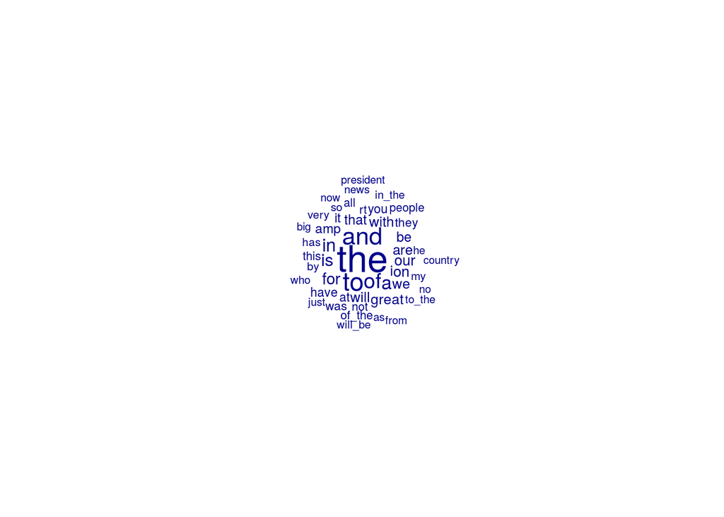

```r
textplot_wordcloud(twdfm, rotation=0, min_size=.75, max_size=3, max_words=50)
```

```r
topfeatures(twdfm, 25)
```

```
##   the    to   and    of     a    in    is   for    on   our  will great
##  4580  2697  2493  1945  1549  1455  1299  1088   920   887   836   825
##  with   are    we     i    be  that   amp    it  have    at   you   was
##   815   793   764   735   714   707   637   601   536   523   520   492
##  they
##   474
```

We can remove the stopwords when we create the `dfm` object:

```r
twdfm <- dfm(twcorpus, remove_punct = TRUE, remove=c(
  stopwords("english"), "t.co", "https", "rt", "amp", "http", "t.c", "can", "u"), remove_url=TRUE, verbose=TRUE)
```

```
## Creating a dfm from a corpus input...
```

```
##    ... lowercasing
```

```
##    ... found 3,866 documents, 8,456 features
```

```
##    ... removed 165 features
##    ... created a 3,866 x 8,291 sparse dfm
##    ... complete.
## Elapsed time: 0.27 seconds.
```

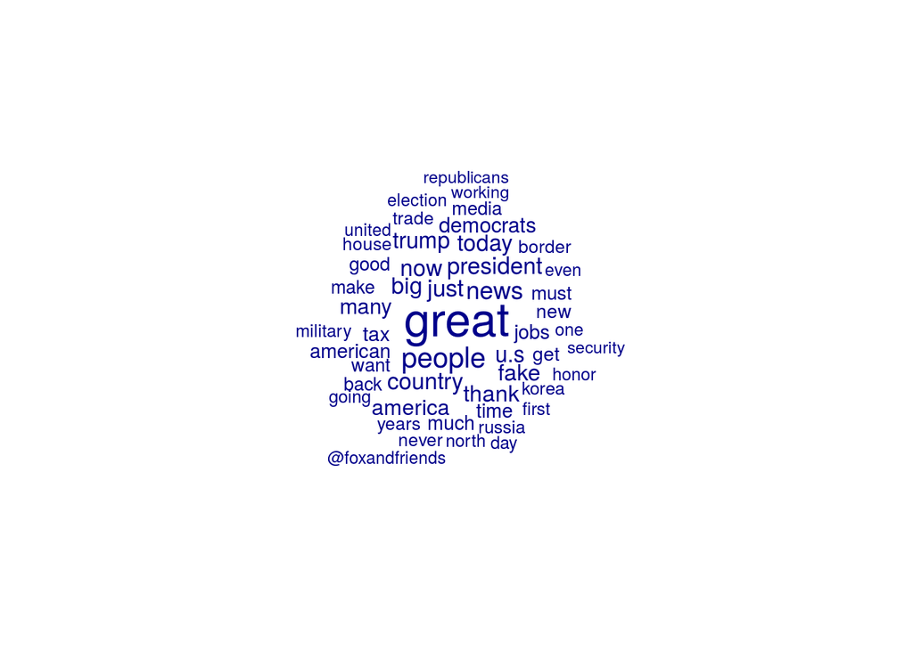

```r
textplot_wordcloud(twdfm, rotation=0, min_size=.75, max_size=3, max_words=50)
```